# Core Stats Notebook

# 1. Statistical Inference

We will look at one-sample data, two-sample data, and paired data. We will need the following libraries:

```r
library(tidyverse)
```

## 1.1. One-Sample data

We will begin with the example of male guppies collected from the Guanapo River in Trinidad. Suppose we measure their body lengths and we want to test whether the data support the hypothesis that the mean body is actually 20mm. So we have the following null and alternative hypotheses:

$H_0:$ The mean body length is equal to 20mm ($\mu = 20$). $H_1:$ The mean body length is not equal to 20mm ($\mu \neq 20$).

To test this we will use a one-sample, two tailed t-test to see if we should reject the null hypothesis or not. We use two-tailed t-test because we are not testing whether the mean is greater than or less than 20mm. We are only testing if it is different from 20mm.

First lets get the data, summarize and visualize it:

```r
summary(fishlengthDF)
```

```
       id        river               length
 Min.   : 1   Length:29          Min.   :11.2
 1st Qu.: 8   Class :character   1st Qu.:17.5
 Median :15   Mode  :character   Median :18.8
 Mean   :15                      Mean   :18.3
 3rd Qu.:22                      3rd Qu.:19.7
 Max.   :29                      Max.   :23.3
```

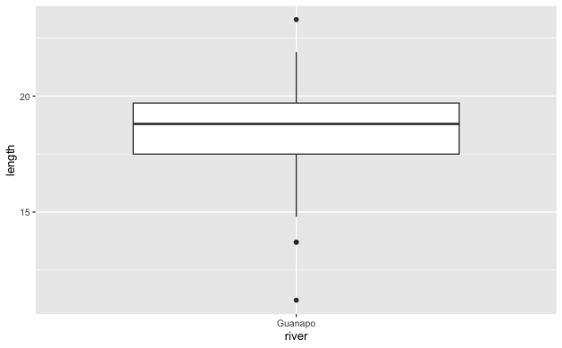

```r
ggplot(fishlengthDF,
       aes(x = river,
           y = length)) +
  geom_boxplot()
```

The data do not appear to contain any obvious errors. Although mean and median are less than 20, it is not absolutely certain that the sample mean is sufficiently different from this value to be “statistically significant”.

### 1.1.1. Assumptions

When it comes to one-sample tests, we have two options: t-test and Wilcoxon signed-rank test.

To use a t-test we have to make two assumptions: parent distribution from which the sample is taken is normally distributed, and data in the sample are independent. The first assumption can be checked. There are three ways of checking for normality. In order of rigor, these are: a) Histogram b) Quantile-Quantile (Q-Q) plot c) Shapiro-Wil test

#### 1.1.1.a. Histogram

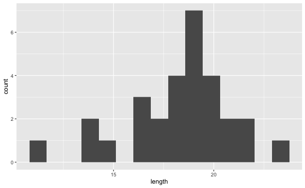

```r
ggplot(fishlengthDF,
       aes(x = length)) +
  geom_histogram(bins = 15)
```

From the histogram we can see that the distribution is unimodal and symmetric, so we can’t clearly conclude that it is non-normal. But there are a lot of distributions that have these properties but not normal. So this is not very rigorous.

#### 1.1.1.b. Q-Q Plot

Sometimes referred to as Diagnostic plot, Q-Q plot is a way of comparing two distributions: one of the data and one of the theoretical normal distribution

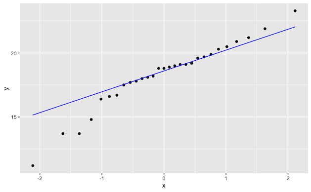

```r
ggplot(fishlengthDF,
       aes(sample = length)) +
  stat_qq() +
  stat_qq_line(color = "blue")
```

If the data were normally distributed then all of the points should lie on, or close to, the diagonal line. Here, the tails of the distribution are below and above the line so they are a bit more spread out than normal. There is not a simple unambiguous answer when interpreting these in terms of whether the assumption of normality has been met or not. It often boils down to experience. It is a very rare situation where the assumptions necessary for a test will be met unequivocally and a certain degree of interpretation is needed to decide if the data are normal enough to be confident in the validity of the test.

#### 1.1.1.c. Shapiro-Wilk test

This is one of a number of formal statistical test that assesses whether a given sample of numbers come from a normal distribution. It calculates the prob. of getting the sample data if the underlying distribution is in fact normal.

```r
shapiro.test(fishlengthDF$length)
```

```
    Shapiro-Wilk normality test

data:  fishlengthDF$length
W = 0.94938, p-value = 0.1764
```

The output: 1st line gives the name of the test and “data:” tells you which data are used 3rd line contains two key outputs from the test: The calculated W-statistic is 0.9494, and the p-value is 0.1764.

Since the p-value is larger than say 0.05, we can say that there is insufficient evidence to reject the null hypothesis that the sample came from a normal distribution.

It is important to note the limitations of Shapiro-Wilk test, in that it is sensitive to the sample sizes. In general, for small sample sizes, the test is very relaxed about normality and nearly all data sets are considered normal; while for large sample sizes the test can be overly strict, and it can fail to recognize data sets that are very nearly normal indeed.

If not happy, though, we could consider an alternative test that has less stringent assumptions but also less powerful: the one-sample Wilcoxon signed-rank test.

Now we are ready to run the t-test.

### 1.1.2. t-test and its interpretation

```r
t.test(fishlengthDF$length,
       mu = 20, alternative = "two.sided")
```

```
    One Sample t-test

data:  fishlengthDF$length
t = -3.5492, df = 28, p-value = 0.001387
alternative hypothesis: true mean is not equal to 20
95 percent confidence interval:
 17.31341 19.27969
sample estimates:
mean of x
 18.29655
```

```r
# the first argument must be a numerical vector of data values, In our case it is the 'length' values.
# the secons argument must be a number and is the mean to be tested under the null hypothesis.
# the third argument gives the type of alternative hypothesis and must be one of 'two.sided', 'greater', or 'less'.
```

In the output: 1st line gives the name of the test and the 2nd line reminds you on what data the test is applied 3rd line contains three key outputs from the test: calculated t-value which is needed for reporting, degrees of freedom which is also needed for reporting, and the p-value. 4th line states the alternative hypothesis 5th and 6th line gives the 95% confidence interval. If you want to change the this, you can put in the argument conf.level = 0.99 7th, 8th, and 9th lines give the sample mean

In this case the confidence interval does not include our 20mm and the p-value is much smaller than 0.05 so we reject the null hypothesis and state the following: “A one-sample t-test indicated that the mean body length of male guppies (18.29mm) differs significantly from 20mm (t=-3.55, p=0.0014, CI=[17.31,19.28])